# Analisis Perilaku Pelanggan - Database Sakila

Muhammad Farel Arrauf | M0725045 | B

2026-05-26

# Deskripsi Insight

**Pertanyaan:** Bagaimana pola perilaku pelanggan dalam menyewa film di toko Sakila? Siapa pelanggan bernilai tinggi yang perlu diprioritaskan?

Analisis ini menggunakan metode **RFM (Recency, Frequency, Monetary)** untuk memetakan perilaku 599 pelanggan berdasarkan riwayat transaksi sewa dan pembayaran di database Sakila.

| Variabel | Keterangan |
| --- | --- |
| Recency | Hari sejak transaksi terakhir |
| Frequency | Jumlah total transaksi sewa |
| Monetary | Total pengeluaran pelanggan (USD) |

# Pengambilan Data

```r
con <- dbConnect(RMySQL::MySQL(), dbname = "sakila", host = "127.0.0.1",
                 port = 3306, user = "root", password = "Surorejo01")

df <- dbGetQuery(con, "
  SELECT c.customer_id,
         CONCAT(c.first_name, ' ', c.last_name) AS nama,
         MAX(r.rental_date)          AS last_rental,
         COUNT(DISTINCT r.rental_id) AS frequency,
         SUM(p.amount)               AS monetary
  FROM customer c
  JOIN rental  r ON c.customer_id = r.customer_id
  JOIN payment p ON r.rental_id   = p.rental_id
  GROUP BY c.customer_id, c.first_name, c.last_name
")
dbDisconnect(con)
```

```
## [1] TRUE
```

```r
rfm <- df %>%
  mutate(
    last_rental = as.Date(last_rental),
    recency     = as.numeric(as.Date("2006-02-15") - last_rental),
    monetary    = round(as.numeric(monetary), 2)
  )

glimpse(rfm)
```

```
## Rows: 599
## Columns: 6
## $ customer_id <dbl> 1, 2, 3, 4, 5, 6, 7, 8, 9, 10, 11, 12, 13, 14, 15, 16, 17,…
## $ nama        <chr> "MARY SMITH", "PATRICIA JOHNSON", "LINDA WILLIAMS", "BARBA…
## $ last_rental <date> 2005-08-22, 2005-08-23, 2005-08-23, 2005-08-23, 2006-02-1…
## $ frequency   <dbl> 32, 27, 26, 22, 38, 28, 33, 24, 23, 25, 24, 28, 27, 28, 32…
## $ monetary    <dbl> 118.68, 128.73, 135.74, 81.78, 144.62, 93.72, 151.67, 92.7…
## $ recency     <dbl> 177, 176, 176, 176, 1, 176, 178, 176, 1, 177, 1, 176, 177,…
```

# Analisis RFM

## Skoring

Formula skoring menggunakan **kuintil** — setiap variabel dibagi 5 kelompok dengan skor 1–5.

$$\text{RFM Score} = R\_Score + F\_Score +
M\_Score$$

Untuk Recency, skor dibalik karena nilai recency rendah (transaksi lebih baru) justru lebih baik:

$$R\_Score = 6 -
\text{kuintil}(Recency)$$

```r
q_score <- function(x, rev = FALSE) {
  s <- cut(x, breaks = unique(quantile(x, seq(0, 1, 0.2))),
           labels = FALSE, include.lowest = TRUE)
  s[is.na(s)] <- 1
  if (rev) 6 - s else s
}

df_seg <- rfm %>%
  mutate(
    R      = q_score(recency,   rev = TRUE),
    F      = q_score(frequency),
    M      = q_score(monetary),
    RFM    = R + F + M,
    Segmen = case_when(
      RFM >= 13 ~ "VVIP",
      RFM >= 10 ~ "Setia",
      RFM >= 7  ~ "Lumayan Setia",
      RFM >= 4  ~ "Hampir Ga Setia",
      TRUE      ~ "Ga Setia"
    )
  )
```

## Statistik Deskriptif

```r
summary(rfm[, c("recency", "frequency", "monetary")])
```

```
##     recency        frequency        monetary
##  Min.   :  1.0   Min.   :12.00   Min.   : 50.85
##  1st Qu.:  1.0   1st Qu.:23.00   1st Qu.: 94.78
##  Median :176.0   Median :26.00   Median :110.73
##  Mean   :130.2   Mean   :26.78   Mean   :112.53
##  3rd Qu.:177.0   3rd Qu.:30.00   3rd Qu.:128.71
##  Max.   :182.0   Max.   :46.00   Max.   :221.55
```

## Distribusi Segmen

```r
df_seg %>%
  group_by(Segmen) %>%
  summarise(Jumlah = n(), Avg_Freq = round(mean(frequency), 1),
            Avg_Monetary = round(mean(monetary), 2),
            Total_Rev = round(sum(monetary), 2)) %>%
  arrange(desc(Total_Rev))
```

```
## # A tibble: 4 × 5
##   Segmen          Jumlah Avg_Freq Avg_Monetary Total_Rev
##   <chr>            <int>    <dbl>        <dbl>     <dbl>
## 1 VVIP               173     32.6        141.     24469.
## 2 Setia              194     27.3        114.     22128.
## 3 Lumayan Setia      193     22.5         91.9    17735.
## 4 Hampir Ga Setia     39     19.6         78.8     3075.
```

# Visualisasi Data

## 1. Distribusi Frequency dan Monetary

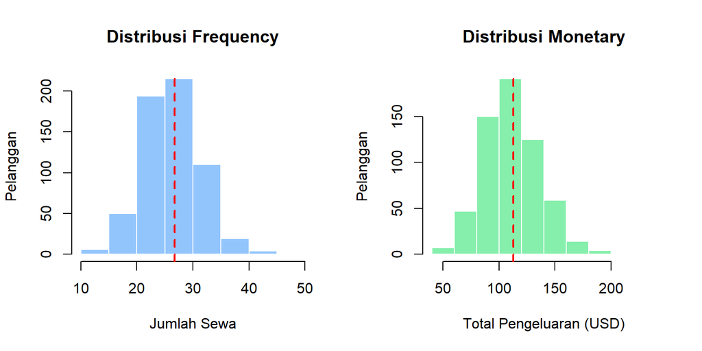

```r
par(mfrow = c(1, 2))
hist(rfm$frequency, col = "#93C5FD", border = "white",
     main = "Distribusi Frequency", xlab = "Jumlah Sewa", ylab = "Pelanggan")
abline(v = mean(rfm$frequency), col = "red", lty = 2, lwd = 2)

hist(rfm$monetary, col = "#86EFAC", border = "white",
     main = "Distribusi Monetary", xlab = "Total Pengeluaran (USD)", ylab = "Pelanggan")
abline(v = mean(rfm$monetary), col = "red", lty = 2, lwd = 2)
```

**Interpretasi:** Distribusi *frequency* cenderung mendekati simetris, menunjukkan sebagian besar pelanggan memiliki jumlah sewa yang hampir sama. Sebaliknya, distribusi *monetary* cenderung miring kanan, artinya mayoritas pelanggan memiliki pengeluaran rendah hingga menengah, namun ada sebagian kecil pelanggan dengan pengeluaran yang jauh di atas rata-rata (garis merah menunjukkan mean).

## 2. Distribusi Segmen Pelanggan

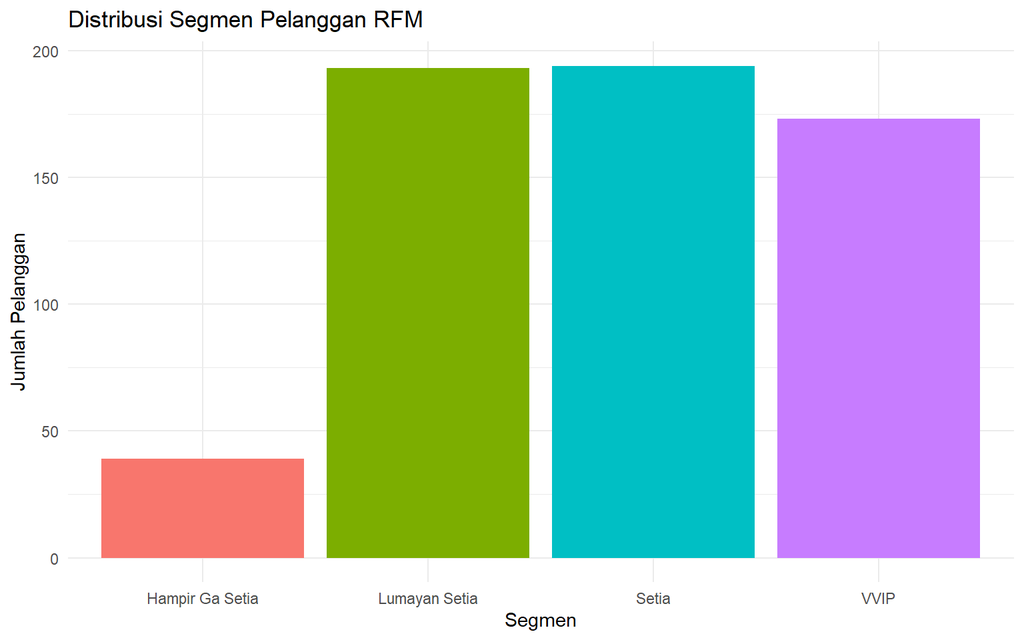

```r
ggplot(df_seg, aes(x = Segmen, fill = Segmen)) +
  geom_bar(show.legend = FALSE) +
  labs(title = "Distribusi Segmen Pelanggan RFM", x = "Segmen", y = "Jumlah Pelanggan") +
  theme_minimal()
```

## 3. Hubungan Frequency dan Monetary

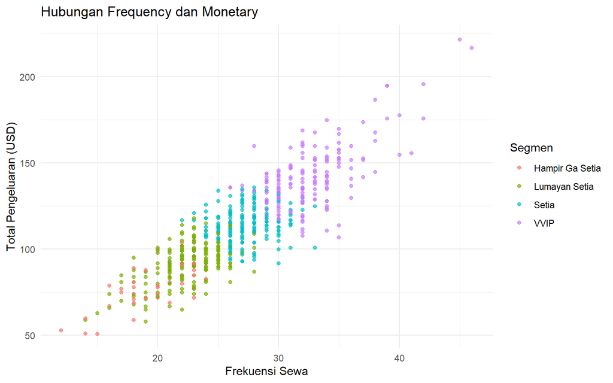

```r
ggplot(df_seg, aes(x = frequency, y = monetary, color = Segmen)) +
  geom_point(alpha = 0.7) +
  labs(title = "Hubungan Frequency dan Monetary",
       x = "Frekuensi Sewa", y = "Total Pengeluaran (USD)") +
  theme_minimal()
```

**Interpretasi:** Scatter plot menunjukkan pola sebaran yang jelas ke arah kanan atas — semakin tinggi frekuensi sewa, semakin besar pula total pengeluaran pelanggan. Titik-titik berwarna yang merupakan pelanggan dengan segmen **VVIP** (skor tertinggi) terkonsentrasi di sudut kanan atas, mengonfirmasi bahwa segmen ini memang unggul di kedua dimensi sekaligus.

# Analisis Statistik: Korelasi Pearson

$$r = \frac{\sum(F_i - \bar{F})(M_i -
\bar{M})}{\sqrt{\sum(F_i - \bar{F})^2 \cdot \sum(M_i -
\bar{M})^2}}$$

```r
uji <- cor.test(df_seg$frequency, df_seg$monetary, method = "pearson")
cat("Koefisien Korelasi (r) :", round(uji$estimate, 4), "\n")
```

```
## Koefisien Korelasi (r) : 0.8707
```

```r
cat("p-value                :", format(uji$p.value, scientific = TRUE), "\n")
```

```
## p-value                : 4.099419e-186
```

```r
cat("Interval Kepercayaan   :", round(uji$conf.int, 4), "\n")
```

```
## Interval Kepercayaan   : 0.8498 0.8888
```

# Interpretasi

**3. Korelasi Frequency–Monetary** Korelasi Pearson menunjukkan hubungan **positif dan signifikan** yang sangat kuat, artinya pelanggan yang lebih sering menyewa cenderung memiliki pengeluaran lebih tinggi.

*Laporan dibuat dengan R-Markdown | Database Sakila | Sistem Informasi Manajemen*